# Data000: 高松市ウェルビーイング lvsem デモ

Analysis

2026-05-10

## 概要

このノートは、高松市ウェルビーイング調査データを使った `lvsem` のデモです。

`wellbeing.csv` は、1行目に領域名、2行目に質問文、3行目以降に回答データが入っています。 ここでは質問項目を5つのブロックにまとめ、`Wellbeing` を結果変数とする構造モデルを推定します。

分析の流れは次の通りです。

- CSVを読み込み、項目と領域を整理する
- 5つの分析ブロックを定義する
- `lvsem` で潜在変数スコアを作成する
- 構造パスと効果を推定する
- 測定モデルの信頼性、AVE、外部負荷量を確認する
- モデル図を作成する

## パッケージ

```r
rm(list = ls(all = TRUE))

library(lvsem)
library(ggplot2)
library(knitr)
```

## データ読み込み

```r
data_file <- "wellbeing.csv"
data_candidates <- c(
  file.path("data000", data_file),
  data_file,
  file.path("..", "data000", data_file)
)
data_path <- data_candidates[file.exists(data_candidates)][1]

if (is.na(data_path)) {
  stop("CSVファイルが見つかりません: ", data_file)
}

data_dir <- dirname(data_path)

meta <- read.csv(
  data_path,
  header = FALSE,
  nrows = 2,
  check.names = FALSE,
  fileEncoding = "CP932"
)

category_jp <- as.character(meta[1, -1])
item_label <- as.character(meta[2, -1])

raw_data <- read.csv(
  data_path,
  header = FALSE,
  skip = 2,
  check.names = FALSE,
  fileEncoding = "CP932"
)

dim(raw_data)
```

```
## [1] 100  56
```

```r
head(raw_data)
```

```
##      V1 V2 V3 V4 V5 V6 V7 V8 V9 V10 V11 V12 V13 V14 V15 V16 V17 V18 V19 V20 V21
## 1 10001       NA  6 NA  5  6  4   4   4   4   4   5   2   3   4   3   1   2   2
## 2 10002       NA  7 NA  7  7  4   4   4   4   4   4   2   4   4   4   4   4   4
## 3 10003       NA 10 NA  9  9  4   5   5   5   5   5   1   2   4   4   4   5   5
## 4 10004       NA  5 NA  5  5  3   5   3   3   1   3   1   4   1   2   4   4   4
## 5 10005       NA  5 NA  7  6  3   4   3   4   3   3   2   4   3   2   4   3   4
## 6 10006       NA  7 NA  9  6  4   4   4   4   4   5   1   4   3   3   3   4   4
##   V22 V23 V24 V25 V26 V27 V28 V29 V30 V31 V32 V33 V34 V35 V36 V37 V38 V39 V40
## 1   4   4   4   2   4   4   4   4   4   4   5   2   4   4   4   5   3   4   4
## 2   4   4   4   4   4   4   3   4   4   4   4   4   4   4   4   4   4   4   4
## 3   5   4   4   4   4   5   4   4   3   4   4   4   4   5   5   4   3   3   3
## 4   4   4   4   3   3   4   3   2   3   4   2   3   4   2   2   3   3   3   4
## 5   3   4   3   3   3   4   3   4   4   3   3   3   3   4   4   4   3   3   4
## 6   4   4   4   3   4   4   4   4   4   4   4   3   3   3   4   4   3   3   4
##   V41 V42 V43 V44 V45 V46 V47 V48 V49 V50 V51 V52 V53 V54 V55 V56
## 1   4   4   2   3   4   3   3   2   2   3   3   2   2   4   3
## 2   4   4   4   4   4   3   4   4   4   4   4   4   4   4   4
## 3   4   3   2   3   4   4   4   4   5   5   5   5   4   5   4
## 4   3   3   2   1   3   3   4   3   4   3   4   4   3   3   3
## 5   4   3   2   4   3   3   3   3   2   3   4   3   3   3   3
## 6   4   3   3   3   4   4   4   4   5   3   4   4   4   4   4
```

## 領域の整理

```r
category_keys <- c(
  "attr", "wellBeing", "healthcare", "shoppingDining", "housing",
  "mobility", "recreation", "childcare", "primarySecondaryEdu",
  "localGovernment", "digitalLife", "publicSpace", "urbanLandscape",
  "naturalLandscape", "naturalResources", "environmentalHarmony",
  "naturalDisasters", "accidentsCrime", "communityConnectedness",
  "diversityTolerance", "selfEfficacy", "healthStatus", "cultureArts",
  "educationalOpportunities", "employmentIncome", "entrepreneurship",
  "original"
)

category_order <- unique(category_jp)
category_index <- match(category_jp, category_order)
item_keys <- make.unique(category_keys[category_index], sep = "_")

names(raw_data) <- c("RespondentID", item_keys)

item_dictionary <- data.frame(
  category_key = category_keys[category_index],
  category = category_jp,
  item_key = item_keys,
  item = item_label,
  stringsAsFactors = FALSE
)

kable(head(item_dictionary, 12), caption = "項目辞書の先頭")
```

項目辞書の先頭

| category_key | category | item_key | item |
| --- | --- | --- | --- |
| attr | 属性 | attr | 性別 |
| attr | 属性 | attr_1 | 年代 |
| attr | 属性 | attr_2 | 住所 |
| wellBeing | 幸福度・満足度 | wellBeing | 現在、あなたはどの程度幸せですか。「とても幸せ」を 10 点、「とても不幸」を0点とすると、何点くらいになると思いますか。いずれかの数字を1つだけお答えください。 |
| wellBeing | 幸福度・満足度 | wellBeing_1 | 今から5年後、あなたはどの程度幸せだと思いますか。「とても幸せ」を 10 点、「とても不幸」を0点とすると、何点くらいになると思いますか。いずれかの数字を1つだけお答えください。 |
| wellBeing | 幸福度・満足度 | wellBeing_2 | 現在、あなたの住んでいる地域の暮らしにどの程度満足していますか。「とても満足」を 10 点、「とても不満足」を0点とすると、何点くらいになると思いますか。いずれかの数字を1つだけお答えください。 |
| wellBeing | 幸福度・満足度 | wellBeing_3 | あなたの町内（集落）の人々は、大体において、どれぐらい幸せだと思いますか。「とても幸せ」を10点、「とても不幸」を0点として、いずれかの数字を1つだけお答えください。ここでは自分の同居家族は除いて考えてください。 |
| wellBeing | 幸福度・満足度 | wellBeing_4 | 自分だけでなく、身近なまわりの人も楽しい気持ちでいると思う |
| healthcare | 医療・福祉 | healthcare | 暮らしている地域は、医療機関が充実している |
| healthcare | 医療・福祉 | healthcare_1 | 私の暮らしている地域では、介護・福祉施設のサービスが受けやすい |
| shoppingDining | 買物・飲食 | shoppingDining | 暮らしている地域は、日常の買い物にまったく不便がない |
| shoppingDining | 買物・飲食 | shoppingDining_1 | 私の暮らしている地域では、飲食を楽しめる場所が充実している |

## モデル定義

このデモでは、調査項目を次の5ブロックにまとめます。

- `Wellbeing`: 幸福度・満足度
- `Health`: 健康状態、医療・福祉
- `Social`: 地域とのつながり
- `Env`: 住宅環境、移動・交通、公共空間、自然景観、都市景観
- `EcoCult`: 雇用・所得、文化・芸術、教育機会の豊かさ、買物・飲食

```r
grouped_items <- split(item_keys, category_keys[category_index])

blocks <- list(
  Wellbeing = grouped_items[["wellBeing"]],
  Health = c(grouped_items[["healthStatus"]], grouped_items[["healthcare"]]),
  Social = grouped_items[["communityConnectedness"]],
  Env = c(
    grouped_items[["housing"]],
    grouped_items[["mobility"]],
    grouped_items[["publicSpace"]],
    grouped_items[["naturalLandscape"]],
    grouped_items[["urbanLandscape"]]
  ),
  EcoCult = c(
    grouped_items[["employmentIncome"]],
    grouped_items[["cultureArts"]],
    grouped_items[["educationalOpportunities"]],
    grouped_items[["shoppingDining"]]
  )
)

block_summary <- data.frame(
  block = names(blocks),
  item_count = vapply(blocks, length, integer(1))
)
kable(block_summary, caption = "分析ブロック")
```

分析ブロック

|  | block | item_count |
| --- | --- | --- |
| Wellbeing | Wellbeing | 5 |
| Health | Health | 4 |
| Social | Social | 5 |
| Env | Env | 8 |
| EcoCult | EcoCult | 7 |

```r
latent_vars <- names(blocks)
path <- matrix(
  0,
  nrow = length(latent_vars),
  ncol = length(latent_vars),
  dimnames = list(latent_vars, latent_vars)
)
path["Wellbeing", c("Health", "Social", "Env", "EcoCult")] <- 1
path
```

```
##           Wellbeing Health Social Env EcoCult
## Wellbeing         0      1      1   1       1
## Health            0      0      0   0       0
## Social            0      0      0   0       0
## Env               0      0      0   0       0
## EcoCult           0      0      0   0       0
```

```r
score_relation <- path + t(path)
score_relation
```

```
##           Wellbeing Health Social Env EcoCult
## Wellbeing         0      1      1   1       1
## Health            1      0      0   0       0
## Social            1      0      0   0       0
## Env               1      0      0   0       0
## EcoCult           1      0      0   0       0
```

## 前処理

```r
model_vars <- unique(unlist(blocks))
model_data <- raw_data[, model_vars, drop = FALSE]

model_data[] <- lapply(model_data, function(x) {
  x <- as.numeric(as.character(x))
  x[!is.finite(x)] <- NA_real_
  x
})

too_constant <- vapply(model_data, function(x) {
  observed <- x[!is.na(x)]
  if (!length(observed)) {
    return(TRUE)
  }
  stats::sd(observed) == 0 || max(table(observed)) / length(observed) >= 0.80
}, logical(1))

if (any(too_constant)) {
  model_data <- model_data[, !too_constant, drop = FALSE]
  blocks <- lapply(blocks, function(x) intersect(x, names(model_data)))
}

model_data[] <- lapply(model_data, function(x) {
  ifelse(is.na(x), stats::median(x, na.rm = TRUE), x)
})

data.frame(
  samples = nrow(model_data),
  variables = ncol(model_data),
  removed_constant_variables = sum(too_constant)
)
```

```
##   samples variables removed_constant_variables
## 1     100        28                          1
```

## 潜在変数スコア

```r
lv_scores <- make_lv_scores(model_data, blocks, score_relation)

head(lv_scores)
```

```
##    Wellbeing      Health      Social        Env    EcoCult
## 1 -1.1554429 -0.90189036  0.45910930  0.6250015 -0.6699975
## 2  0.1611687  0.23998621  0.51821763  0.1330351  0.9992083
## 3  2.3606732  0.95508628  0.07456707  0.9607024  2.5197512
## 4 -2.3980084  0.05001247 -0.19069374 -1.0766676 -0.6876581
## 5 -1.3601242 -0.77212340  0.13997187 -0.3311867 -0.2668526
## 6  0.5481766  0.51408977  0.13997187  0.5891602  0.7410003
```

```r
round(cor(lv_scores), 3)
```

```
##           Wellbeing Health Social   Env EcoCult
## Wellbeing     1.000  0.674  0.440 0.716   0.704
## Health        0.674  1.000  0.211 0.724   0.654
## Social        0.440  0.211  1.000 0.324   0.323
## Env           0.716  0.724  0.324 1.000   0.684
## EcoCult       0.704  0.654  0.323 0.684   1.000
```

## 構造モデル

```r
path_coefficients <- estimate_paths(lv_scores, path, scale_scores = FALSE)
path_effects <- effects_from_beta(path_coefficients)

path_coefficients
```

```
##                   path      beta
## 1  Health_to_Wellbeing 0.6678333
## 2  Social_to_Wellbeing 0.6564387
## 3     Env_to_Wellbeing 0.4868310
## 4 EcoCult_to_Wellbeing 0.4247008
```

```r
path_effects
```

```
##          relationships    direct indirect     total
## 1 EcoCult -> Wellbeing 0.4247008        0 0.4247008
## 2     Env -> Wellbeing 0.4868310        0 0.4868310
## 3  Health -> Wellbeing 0.6678333        0 0.6678333
## 4  Social -> Wellbeing 0.6564387        0 0.6564387
```

```r
lm_fit <- lm(
  Wellbeing ~ Health + Social + Env + EcoCult,
  data = lv_scores
)

structural_table <- data.frame(
  variable = rownames(summary(lm_fit)$coefficients),
  summary(lm_fit)$coefficients,
  row.names = NULL,
  check.names = FALSE
)

kable(
  data.frame(
    variable = structural_table$variable[-1],
    round(structural_table[-1, -1], 3)
  ),
  caption = "構造モデルの推定結果"
)
```

構造モデルの推定結果

|  | variable | Estimate | Std..Error | t.value | Pr…t.. |
| --- | --- | --- | --- | --- | --- |
| 2 | Health | 0.668 | 0.258 | 2.592 | 0.011 |
| 3 | Social | 0.656 | 0.206 | 3.183 | 0.002 |
| 4 | Env | 0.487 | 0.170 | 2.864 | 0.005 |
| 5 | EcoCult | 0.425 | 0.129 | 3.291 | 0.001 |

```r
r2_wellbeing <- summary(lm_fit)$r.squared
adj_r2_wellbeing <- summary(lm_fit)$adj.r.squared
r2_wellbeing
```

```
## [1] 0.6550963
```

```r
adj_r2_wellbeing
```

```
## [1] 0.6405741
```

## Bootstrap

```r
set.seed(123)
boot_paths <- bootstrap_paths(
  model_data,
  blocks,
  path,
  br = 1000,
  seed = 123,
  score_matrix = score_relation
)

kable(
  data.frame(
    path = boot_paths$path,
    round(boot_paths[, c("beta", "boot_se", "t_value")], 3)
  ),
  caption = "Bootstrapによる構造パス"
)
```

Bootstrapによる構造パス

| path | beta | boot_se | t_value |
| --- | --- | --- | --- |
| Health_to_Wellbeing | 0.239 | 0.110 | 2.171 |
| Social_to_Wellbeing | 0.206 | 0.088 | 2.329 |
| Env_to_Wellbeing | 0.277 | 0.119 | 2.331 |
| EcoCult_to_Wellbeing | 0.291 | 0.102 | 2.855 |

## 測定モデルの要約

```r
measures <- measurement_summary(model_data, blocks, lv_scores)

kable(
  data.frame(
    block = measures$reliability$block,
    round(measures$reliability[, c("alpha", "composite_reliability", "ave")], 3)
  ),
  caption = "信頼性とAVE"
)
```

信頼性とAVE

| block | alpha | composite_reliability | ave |
| --- | --- | --- | --- |
| Wellbeing | 0.808 | 0.876 | 0.641 |
| Health | 0.530 | 0.740 | 0.433 |
| Social | 0.761 | 0.830 | 0.496 |
| Env | 0.640 | 0.749 | 0.339 |
| EcoCult | 0.804 | 0.856 | 0.462 |

```r
kable(
  data.frame(
    block = measures$loadings$block,
    item = measures$loadings$item,
    loading = round(measures$loadings$loading, 3)
  ),
  caption = "外部負荷量"
)
```

外部負荷量

| block | item | loading |
| --- | --- | --- |
| Wellbeing | wellBeing | 0.791 |
| Wellbeing | wellBeing_2 | 0.888 |
| Wellbeing | wellBeing_3 | 0.847 |
| Wellbeing | wellBeing_4 | 0.659 |
| Health | healthStatus | 0.713 |
| Health | healthStatus_1 | 0.810 |
| Health | healthcare | 0.668 |
| Health | healthcare_1 | 0.349 |
| Social | communityConnectedness | 0.595 |
| Social | communityConnectedness_1 | 0.752 |
| Social | communityConnectedness_2 | 0.777 |
| Social | communityConnectedness_3 | 0.632 |
| Social | communityConnectedness_4 | 0.748 |
| Env | housing | 0.621 |
| Env | housing_1 | -0.194 |
| Env | housing_2 | 0.219 |
| Env | mobility | 0.537 |
| Env | publicSpace | 0.720 |
| Env | publicSpace_1 | 0.707 |
| Env | naturalLandscape | 0.625 |
| Env | urbanLandscape | 0.735 |
| EcoCult | employmentIncome | 0.759 |
| EcoCult | employmentIncome_1 | 0.655 |
| EcoCult | cultureArts | 0.742 |
| EcoCult | cultureArts_1 | 0.580 |
| EcoCult | educationalOpportunities | 0.721 |
| EcoCult | shoppingDining | 0.595 |
| EcoCult | shoppingDining_1 | 0.686 |

## モデル図

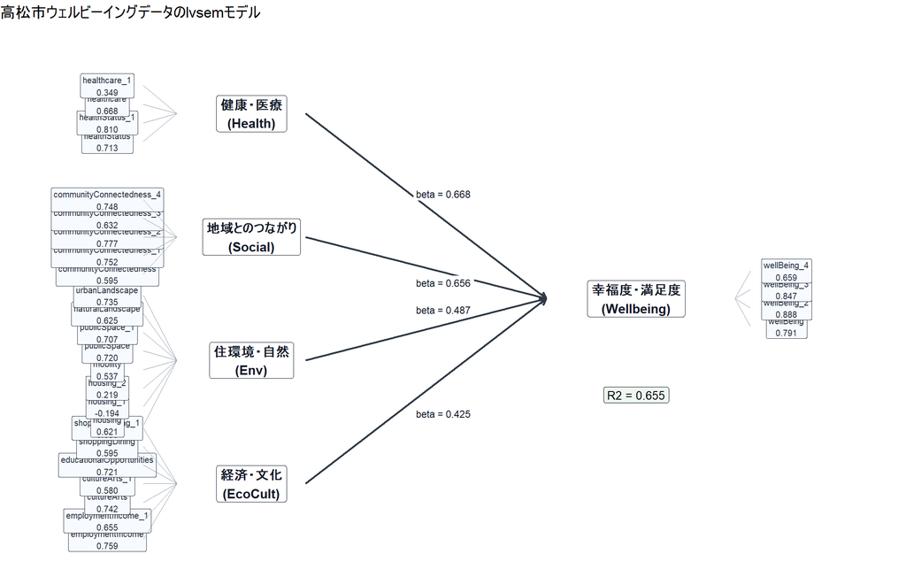

```r
node_df <- data.frame(
  block = c("Health", "Social", "Env", "EcoCult", "Wellbeing"),
  label = c(
    "健康・医療\n(Health)",
    "地域とのつながり\n(Social)",
    "住環境・自然\n(Env)",
    "経済・文化\n(EcoCult)",
    "幸福度・満足度\n(Wellbeing)"
  ),
  x = c(0, 0, 0, 0, 3.2),
  y = c(3, 2, 1, 0, 1.5)
)

edge_df <- data.frame(
  from = sub("_to_Wellbeing", "", path_coefficients$path),
  to = "Wellbeing",
  beta = path_coefficients$beta,
  label = sprintf("beta = %.3f", path_coefficients$beta)
)

edge_df <- merge(
  edge_df,
  node_df[, c("block", "x", "y")],
  by.x = "from",
  by.y = "block"
)
names(edge_df)[names(edge_df) %in% c("x", "y")] <- c("x_from", "y_from")

edge_df <- merge(
  edge_df,
  node_df[, c("block", "x", "y")],
  by.x = "to",
  by.y = "block"
)
names(edge_df)[names(edge_df) %in% c("x", "y")] <- c("x_to", "y_to")

edge_df$x_label <- (edge_df$x_from + edge_df$x_to) / 2
edge_df$y_label <- (edge_df$y_from + edge_df$y_to) / 2 + c(-0.18, 0.16, 0.10, -0.12)

item_df <- measures$loadings
item_df$i <- ave(seq_len(nrow(item_df)), item_df$block, FUN = seq_along)
item_df$n <- ave(seq_len(nrow(item_df)), item_df$block, FUN = length)
item_df <- merge(item_df, node_df[, c("block", "x", "y")], by = "block")
names(item_df)[names(item_df) %in% c("x", "y")] <- c("x_node", "y_node")
item_df$x <- ifelse(item_df$block == "Wellbeing", item_df$x_node + 1.25, item_df$x_node - 1.20)
item_df$y <- item_df$y_node + (item_df$i - (item_df$n + 1) / 2) * 0.15
item_df$label <- sprintf("%s\n%.3f", item_df$item, item_df$loading)

model_plot <- ggplot() +
  geom_segment(
    data = edge_df,
    aes(x = x_from + 0.45, y = y_from, xend = x_to - 0.75, yend = y_to),
    arrow = arrow(length = unit(0.22, "cm")),
    linewidth = 0.8,
    color = "#2f3a45"
  ) +
  geom_label(
    data = item_df,
    aes(x = x, y = y, label = label),
    size = 2.6,
    label.size = 0.25,
    fill = "#f7fbff",
    color = "#2a3340"
  ) +
  geom_segment(
    data = item_df,
    aes(
      x = ifelse(block == "Wellbeing", x - 0.30, x + 0.30),
      y = y,
      xend = ifelse(block == "Wellbeing", x_node + 0.82, x_node - 0.62),
      yend = y_node
    ),
    linewidth = 0.35,
    color = "#8b97a5"
  ) +
  geom_label(
    data = node_df,
    aes(x = x, y = y, label = label),
    size = 4,
    fontface = "bold",
    label.size = 0.35,
    fill = "#ffffff",
    color = "#111827"
  ) +
  geom_label(
    data = edge_df,
    aes(x = x_label, y = y_label, label = label),
    size = 3,
    label.size = 0,
    fill = "#ffffff",
    color = "#111827"
  ) +
  annotate(
    "label",
    x = 3.2,
    y = 0.72,
    label = sprintf("R2 = %.3f", r2_wellbeing),
    size = 3.6,
    label.size = 0.25,
    fill = "#eef7f2"
  ) +
  coord_cartesian(xlim = c(-1.75, 5.10), ylim = c(-0.55, 3.55), clip = "off") +
  theme_void() +
  labs(title = "高松市ウェルビーイングデータのlvsemモデル")

model_plot
```

```r
ggsave(file.path(data_dir, "data000_lvsem_wellbeing_model.png"),
       model_plot, width = 11, height = 7, dpi = 180)
```

## 出力の確認

```r
cat("サンプルサイズ:", nrow(model_data), "\n")
```

```
## サンプルサイズ: 100
```

```r
cat("ウェルビーイングのR2:", round(r2_wellbeing, 3), "\n")
```

```
## ウェルビーイングのR2: 0.655
```

```r
cat("調整済みR2:", round(adj_r2_wellbeing, 3), "\n")
```

```
## 調整済みR2: 0.641
```

## 参考

- ローカルパッケージ: `lvsem`
- データ: `wellbeing.csv`